# COGS2020 Final Project Example

2025-05-08

## Introduction

- The dataset is drawn from a human category learning experiment.
- The dataset is available at:  
  https://github.com/crossley/crit_learn_delay
- This repository contains behavioural data from experiments investigating criterial learning under different feedback delays.

## Example Trial and Basic Stimuli

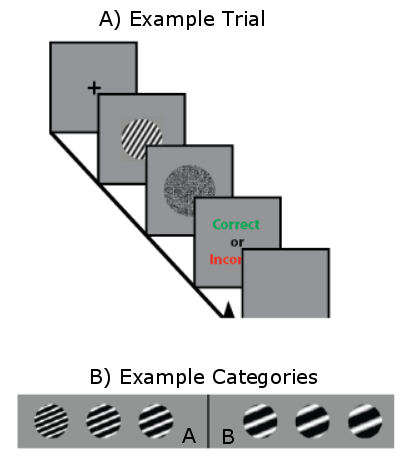

## How Stimuli Are Clustered Into Categories

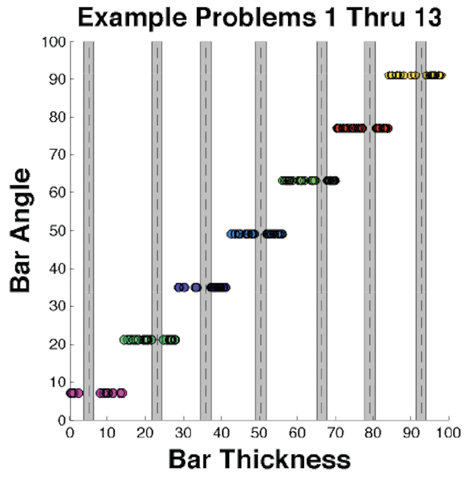

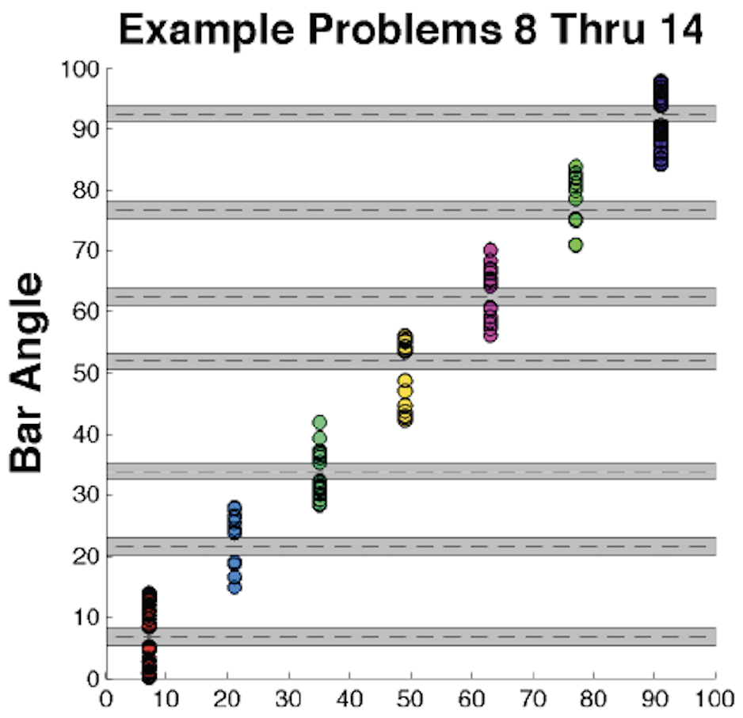

## Example Data File

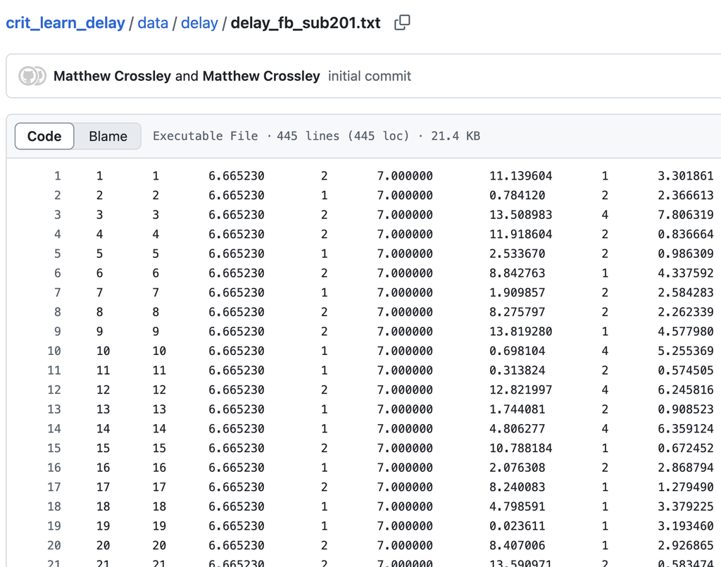

## Data Analysis

- Data files were read in and combined using `data.table` in `R`.
- Each subject completed multiple problems; we computed the **number of trials to reach criterion** (`t2c`) for each problem and averaged across problems for each subject.

## Histogram of Trials to Criterion

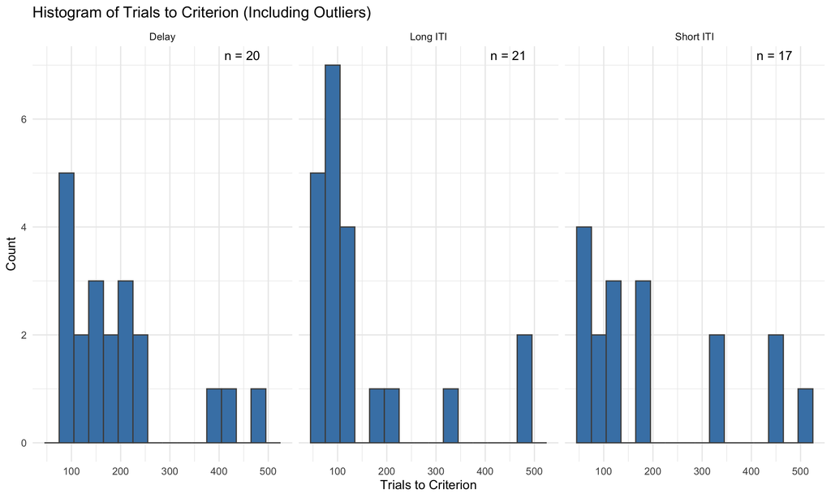

## Identifying and Removing Outliers

- We filtered out **outliers** with `t2c >= 300`.
- Sample sizes per condition before filtering:

```
##          cnd     N
##       <char> <int>
## 1:     Delay    20
## 2:  Long ITI    21
## 3: Short ITI    17
```

- Sample sizes per condition after filtering:

```
##          cnd     N
##       <fctr> <int>
## 1:     Delay    17
## 2:  Long ITI    18
## 3: Short ITI    12
```

## Histogram of Trials to Criterion

[figure not shown]

## Distribution is **not normal**, with positive skew.

- Shapiro-Wilk Test for Normality

| cnd | W | p |
| --- | --- | --- |
| Delay | 0.9191 | 0.1426 |
| Long ITI | 0.8593 | 0.0119 |
| Short ITI | 0.8337 | 0.0232 |

- Normality is **rejected** in Long ITI and Short ITI conditions.
- Despite this, **ANOVA and t-tests** are generally robust to mild violations of normality.

## ANOVA Results

```
##        Effect DFn DFd       SSn    SSd          F            p p<.05       ges
## 1 (Intercept)   1  44 698082.27 106086 289.535175 5.673951e-21     * 0.8680799
## 2         cnd   2  44  26365.99 106086   5.467751 7.571651e-03     * 0.1990608
```

- Significant main effect of condition on `t2c`.
- Proceeded with **pairwise t-tests** to interpret effects.

## Post-hoc t-tests

| Comparison | t_stat | p_val |
| --- | --- | --- |
| Delay vs Long ITI | 3.0986 | 0.0042 |
| Delay vs Short ITI | 2.3223 | 0.0287 |
| Long ITI vs Short ITI | -0.3208 | 0.7516 |

- Delay condition resulted in **significantly more trials** than either Long or Short ITI.
- No significant difference between Long ITI and Short ITI.

## Bar Plot of Group Means

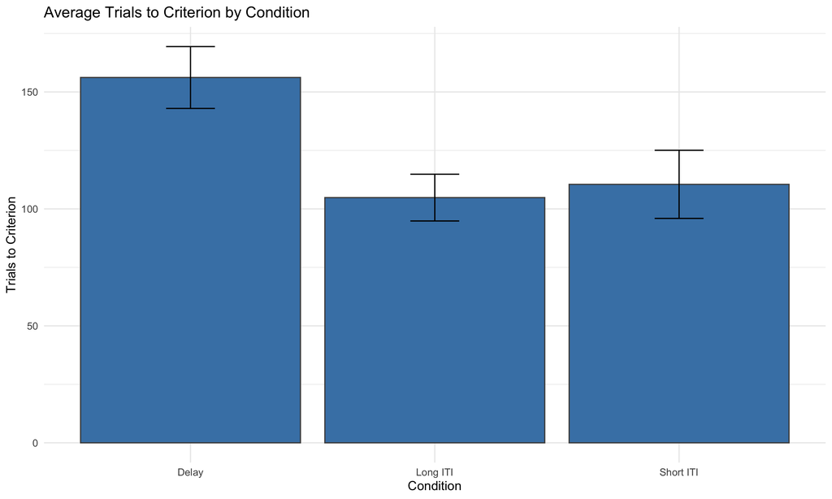

- Clear visual separation of Delay condition from the other two.
- Error bars represent standard error of the mean (SEM).

## Summary

- **Longer feedback delays** led to **slower learning** (higher trials-to-criterion).
- Results support the hypothesis that **delay disrupts criterial learning**.
- Caution is warranted in interpreting results due to non-normality and outliers.